# Prominence across time: which people does each frozen reader know?

Matched domain trios (pre-1900 / 1900-29 / post-1929), 50 free continuations of “*<Name> was*” per person per model, judged by gemini-3.1-flash-lite. Measuring name-knowledge is confounded twice, so we triangulate three passes: the **naive** frame is hijacked by ordinary same-name people (“Richard Wagner was arrested for stealing a bicycle”); a role-**primed** frame fixes that but lets post-1929 people pass as a *generic* period person of that role (a vaudeville “Elvis”); the **era-specific** judge collapses that confabulation.

## Acquisition map (primed frame)

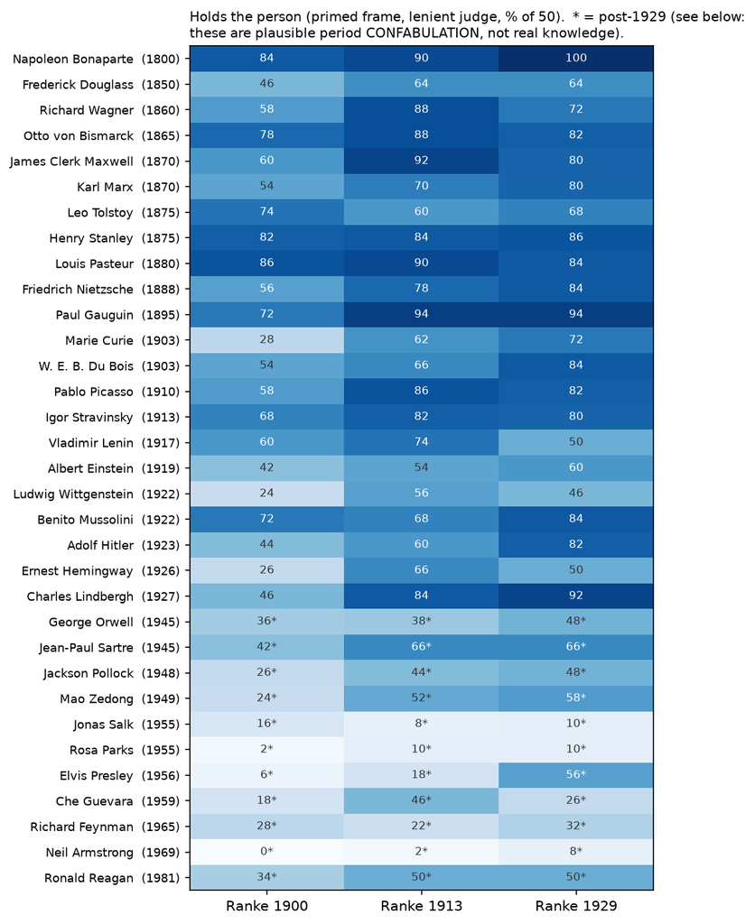

Rows by fame year; columns are the models. Real staircase for pre-1900 and 1900-29 people. The starred post-1929 rows look non-zero only by role-confabulation — see the last figure.

## Matched trios

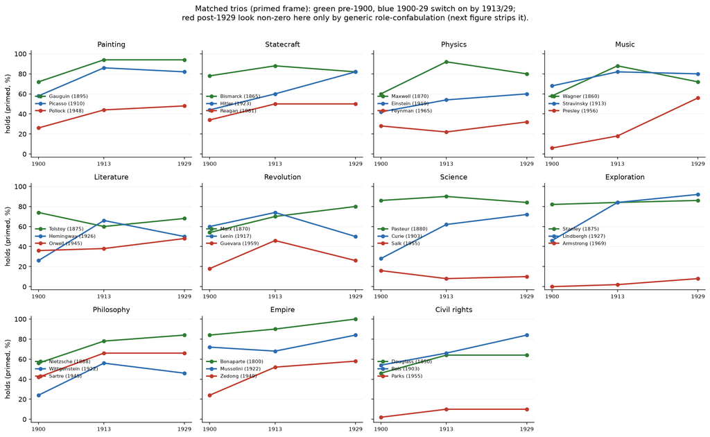

## The metric’s blind spot: plausible confabulation scores like knowledge

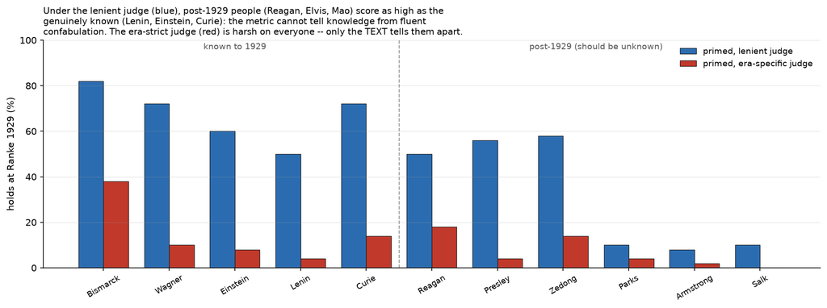

## The two failure modes, in the model’s words (Ranke 1929, primed)

- [NO] “Richard Wagner was born at Leipzig, September 18th, 1926. His father was an organist of talent and a member of the court band. His early musical education”
- [GENERIC] “Richard Wagner was a man of great literary and artistic culture, but the story is told that once during his life he lost his wife. Wagner was very devoted”
- [NO] “Richard Wagner was born in 1926 at Dusseldorf. He died in Bayreuth, Bavaria on August %. In youth he studied law and then COM posed songs for the piano wi”

### Elvis Presley — generic period confabulation (a 1920s vaudeville singer)

- [NO] “Elvis Presley was in New York during the week and was heard at a concert given by Nine. Schumann-Heink, who is to tour this country with her son, Henry C”
- [NO] “Elvis Presley was in his usual good form yesterday afternoon when he sang the popular song "My Sweetie," at a musical given by Mrs. T.. r. Sibley, Jr., f”
- [NO] “Elvis Presley was the principal attraction at Keith's last evening. He sang three songs, "a Little Bit of Heaven" by Homer; I'm Looking for My Sweetie," ”

### Ronald Reagan — a generic stage actor, not the president

- [NO] “Ronald Reagan was killed in battle last week. A brother, a member of the British Parliament and former secretary to Lloyd George has also fallen on the f”
- [NO] “Ronald Reagan was born in Ireland, his father being a wealthy land owner. His mother came from Philadelphia and the family lived for some time at 1873 Wa”
- [YES] “Ronald Reagan was once the hero OF a melodrama, and as such he had been cast for the part Of q poor boy. He played 1t with fine feeling but when at the e”